# Strategic Targeting of OncomiRs in Brain Tumor Therapy: A Gene Expression Analysis Approach

### Heatmap

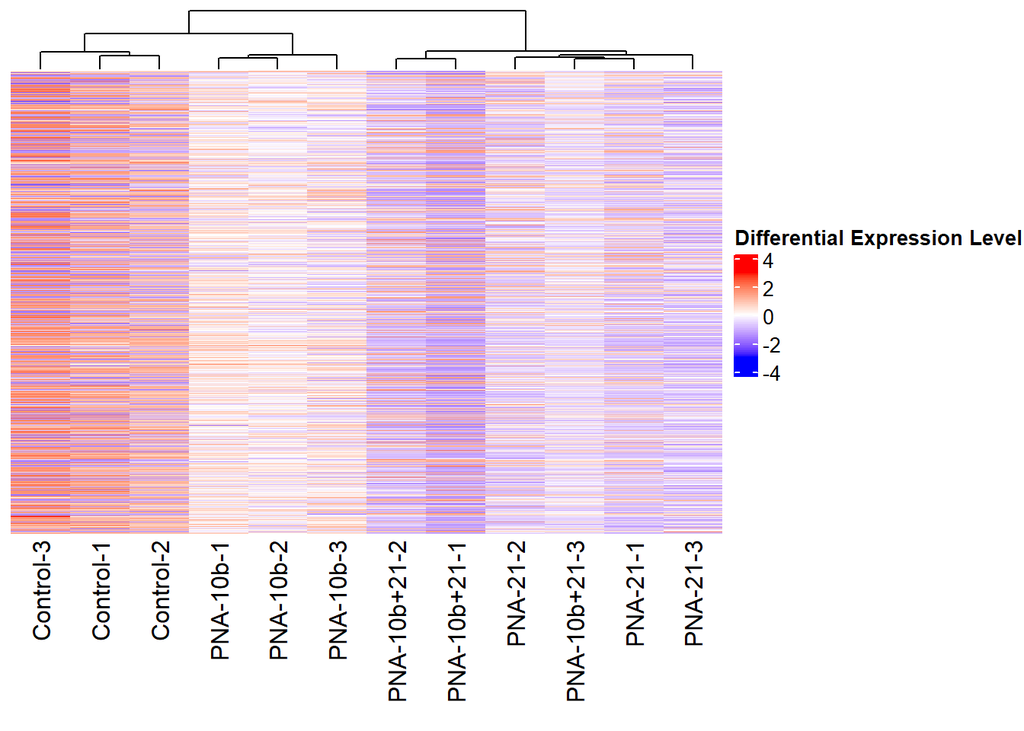

Figure 4. Heatmap of tophits that have a p-value < 0.05. Note the clustering of similar groups together

```r
# Subset the ExpDataset to only include rows with qlf p-value < 0.05
subset_data <- ExpDataset[p.value < 0.05, ]

# Create a heatmap matrix with subsetted data
heatmap_matrix2 <- subset_data[, 3:ncol(subset_data)]
rownames(heatmap_matrix2) <- subset_data$ensembl_gene_id
colnames(heatmap_matrix2) <- colnames(subset_data[, 3:ncol(subset_data)])

# Normalize the data
heatmap_matrix2 <- t(scale(t(heatmap_matrix2)))

# Create a heatmap using ComplexHeatmap
library(ComplexHeatmap)
ht <- Heatmap(heatmap_matrix2, name = "Differential Expression Level",
              col = colorRamp2(c(-3,0,3), c("blue", "white", "red")),
              cluster_rows = FALSE, cluster_columns = TRUE, show_row_dend = FALSE,
              show_row_names = FALSE)
ht
```

## Thresholded over-representation analysis

### Method

I used gprofiler since this database is updated regularly. Moreover, there was a package associated with database (gprofiler2) that enabled me to use it directly from my R notebook.

### Data Annotation

I used the recommended annotation datas in the lecture which were GO:BP (version : releases/2022-12-04), Reactome (version : 2022-12-28) and wikipathway(version : 2022-12-10).

## Interpretation

### Supprot for the paper

Our treatment resulted in the downregulation of genes associated with hypoxia and oxygen response pathways, which are crucial for tumor cell activity and viability.